# 9.3 - Modelos autorregresivos para series temporales

26 de marzo de 2020

## Modelos para series temporales

## Introducción

- Un gran número de modelos para series temporales asumen que, o bien la serie **es estacionaria**, o bien **se puede convertir en estacionaria** mediante algún tipo de **transformación**.
  - También existen modelos para series temporales no estacionarias. Por ejemplo, los modelos AR se pueden aplicar a series no estacionarias.
- Los modelos más simples son los **autorregresivos** (AR), que generalizan la idea de regresión para aplicarla a datos de series temporales. En este caso, el valor de la serie en el instante \(t\) depende de los valores de la serie en todos los instantes anteriores, por lo que son procesos de **memoria larga**.
- Por otro lado, tenemos los modelos de **media móvil** que permiten explicar series temporales (procesos estocásticos) de **memoria corta**. En estos, el valor de la serie en el instante \(t\) depende solo de los valores en unos pocos instantes previos.
- La mezcla de ambos modelos se denominan modelos ARMA.
- Finalmente, los modelos ARIMA permiten extender los modelos anteriores para el caso particular de **series no estacionarias** que denominamos **integradas**.

## Modelos AR

- El primer tipo de modelos son los llamados **procesos autorregresivos**. La serie \(\{x_t\}\) es autorregresiva de orden \(p\), abreviado como AR(p) si se puede modelar como:

\[x_t = \alpha_1x_{t-1} + \alpha_2x_{t-2} + \ldots + \alpha_px_{t-p}+w_t\]

- En esta ecuación, ya se está considerando que a la serie temporal \(\{x_t\}\) le hemos restado su media (eliminando así un término constante que quedaría al principio de la ecuación) [Peña 2005].
- Por tanto, un proceso estocástico se puede modelar como AR(p) si se puede representar como una combinación lineal de \(k\) estados anteriores del proceso \((x_{t-1}, x_{t-2}, \ldots, x_{t-k})\), para \(k > 0\), más una componente de ruido blanco, \(w_t\).
- En el caso particular de AR(1) con \(\alpha_1 = 1\), tenemos una serie temporal cuyo valor actual solo depende de forma lineal del último valor observado (lo que se conoce como un *proceso de Markov*). Esta serie en particular se denomina paseo aleatorio (**random walk**):

\[x_t=x_{t-1}+w_t\]

## Ejemplo: simulación de 50 paseos aleatorios

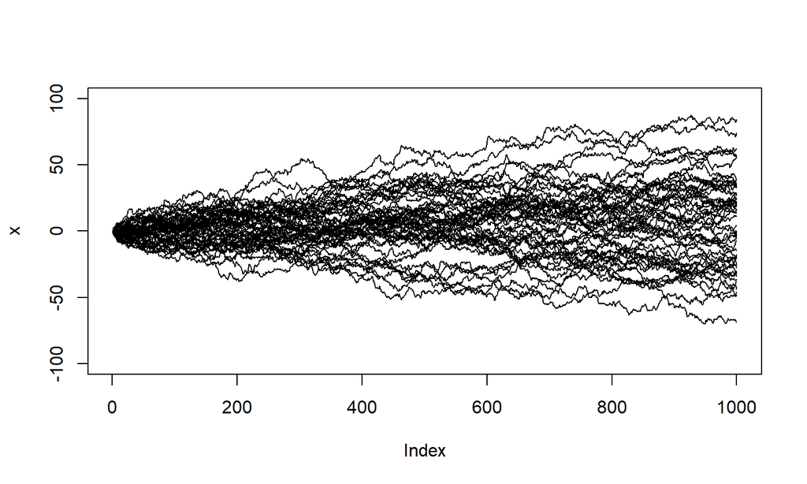

```r
for (i in 1:50) {
  x = w = rnorm(1000)
  for (t in 2:1000){x[t] = x[t-1] + w[t]}
  if (i==1) plot(x, type = 'l', ylim = c(-100, 100)) else lines(x, type = 'l')
}
```

## ACF de un paseo aleatorio

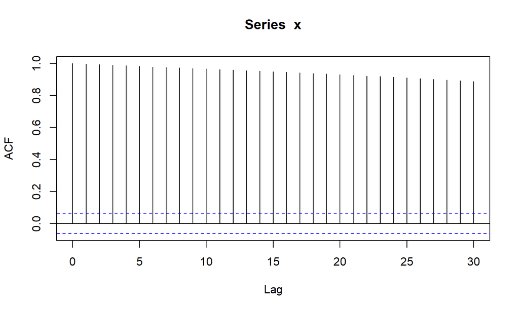

```r
acf(x)  # Decaimiento exponencial característico de este tipo de procesos
```

## ACF de un ruido blanco Gaussiano

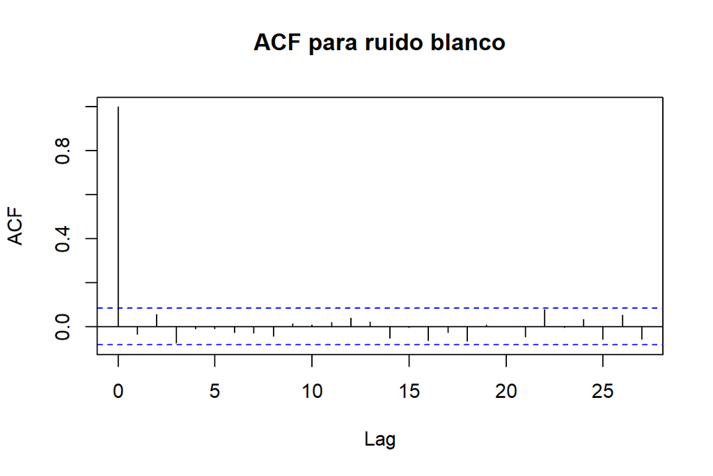

Correlograma para un ruido blanco.

```r
acf(ts(rnorm(550,0,1)), main="ACF para ruido blanco")
```

## Condición de estacionariedad

- Es fácil comprobar a simple vista que un paseo aleatorio no es un proceso estacionario. La serie de valores puede tender a crecer o disminuir, pero normalmente no se estabiliza en torno a un valor medio.
- En general, para que un proceso AR(p) sea **estacionario** se debe cumplir que:

\[|\alpha_i| < 1 \quad i=1, 2, \ldots, p\]

- Por ejemplo, para el caso del paseo aleatorio \(\alpha_1 = 1\) y por tanto no cumple la condición anterior.

## PACF y detección de modelos AR(p)

- Como hemos visto, una característica de los modelos autorregresivos es que su función de autocorrelación (ACF) decae exponencialmente para retardos cada vez mayores.
- Sin embargo, puesto que la serie temporal solo depende de \(p\) valores pasados respecto al valor actual, su función de autocorrelación parcial (PACF) tendrá \(p\) componentes distintas de cero y el resto nulas.

```r
set.seed(1)
x = w = rnorm(100)
# Creamos un proceso estacionario AR(1)
for (t in 2:100) x[t] = 0.7 * x[t-1] + w[t]
```

## PACF y detección de modelos AR(p)

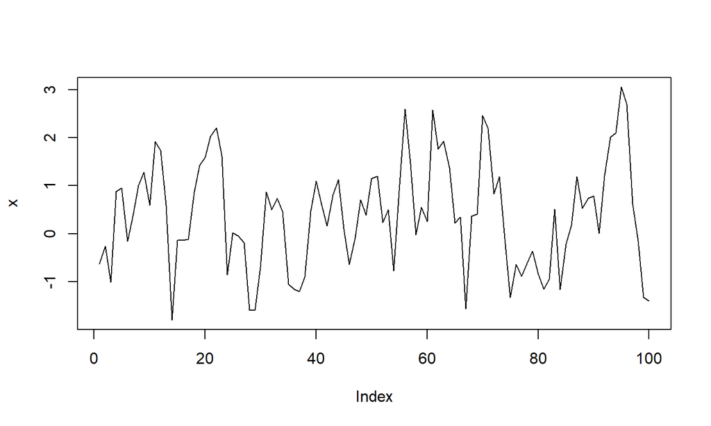

```r
plot(x, type = "l")
```

## PACF y detección de modelos AR(p)

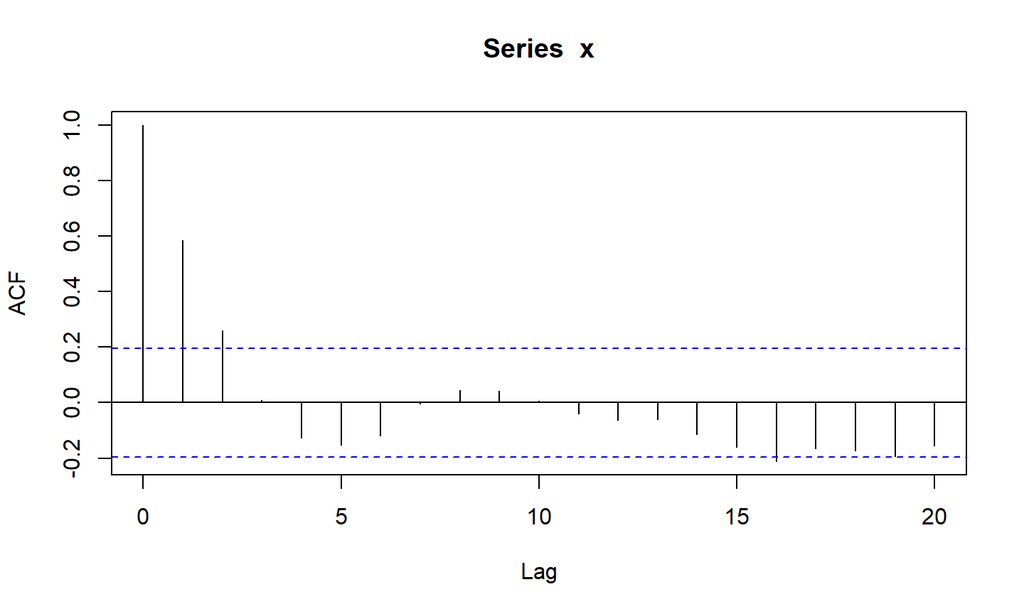

```r
acf(x)  # Las componentes decaen exponencialmente
```

## PACF y detección de modelos AR(p)

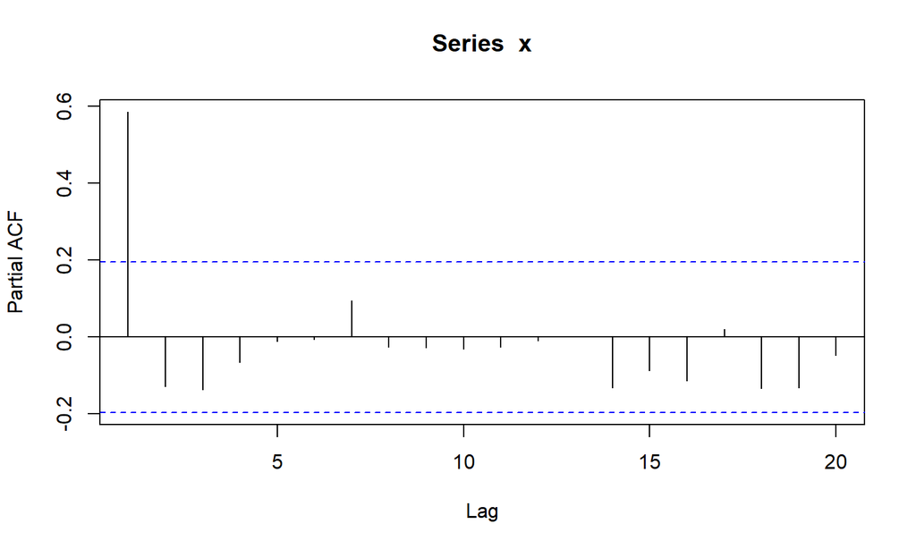

```r
pacf(x)  # Primer valor no nulo, para el resto de retardos valores nulos
```

## Ajuste de modelos AR(p)

- En R, podemos utilizar la función `ar` para ajustar un modelo autorregresivo a una serie de datos temporales. El siguiente ejemplo muestra cómo podemos estimar el valor del coeficiente de autorregresión para la simulación anterior, de un proceso estacionario AR(1) con \(\alpha_1 = 0.7\)

```r
x_armod = ar(x, method = "mle")  # Estimación por máxima verosimilitud
x_armod$order  # Orden del proceso AR, elegido mediante AIC
```

```
## [1] 1
```

```r
x_armod$ar  # valor del parámetro de autoregressión
```

```
## [1] 0.6009459
```

```r
lo = x_armod$ar - qnorm(.975)*sqrt(x_armod$asy.var)
up = x_armod$ar + qnorm(.975)*sqrt(x_armod$asy.var)
c(lo, up)
```

```
## [1] 0.4436169 0.7582749
```